# Lab 4: Sequential Data

This lab is based on an assignment developed by Prof. Lisa Zhang.

In this assignment, we will build a recurrent neural network to classify a SMS text message as "spam" or "not spam". In the process, you will

1. Clean and process text data for machine learning.
2. Understand and implement a character-level recurrent neural network.
3. Use torchtext to build recurrent neural network models.
4. Understand batching for a recurrent neural network, and use torchtext to implement RNN batching.
5. Understand how transfer learning can be applied to NLP projects.

### What to submit

Submit an HTML file containing all your code, outputs, and write-up from parts A and B. You can produce a HTML file directly from Google Colab. The Colab instructions are provided at the end of this document.

**Do not submit any other files produced by your code.**

Include a link to your colab file in your submission.

Please use Google Colab to complete this assignment. If you want to use Jupyter Notebook, please complete the assignment and upload your Jupyter Notebook file to Google Colab for submission.

## Colab Link

Include a link to your colab file here

Colab Link: https://colab.research.google.com/drive/1k1juY9AtOajIXqNZqCIvdii7_XYVSAqn#scrollTo=M0jLI9LBa90C

# PART A - Spam Detection [30 pt]

In this part we will construct a LSTM model for identifying spam from non spam messages.

```python
import torch
import torch.nn as nn
import torch.nn.functional as F
import torch.optim as optim
import numpy as np
```

```python
torch.manual_seed(1)
```

```
<torch._C.Generator at 0x7faad98aa0d0>
```

## Part 1. Data Cleaning [10 pt]

We will be using the "SMS Spam Collection Data Set" available at http://archive.ics.uci.edu/ml/datasets/SMS+Spam+Collection

There is a link to download the "Data Folder" at the very top of the webpage. Download the zip file, unzip it, and upload the file `SMSSpamCollection` to Colab.

### Part (a) [1 pt]

Open up the file in Python, and print out one example of a spam SMS, and one example of a non-spam SMS.

What is the label value for a spam message, and what is the label value for a non-spam message?

```python
for line in open('SMSSpamCollection'):
  first_word = line.split()[0]

  if first_word == 'spam':
    print("label value for a spam message: ", first_word, "[1]")
    break

for line in open('SMSSpamCollection'):
  first_word = line.split()[0]

  if first_word != 'spam':
    print("label value for a non-spam message: ", first_word, "[0]")
    break
```

```
label value for a spam message:  spam [1]
label value for a non-spam message:  ham [0]
```

### Part (b) [1 pt]

How many spam messages are there in the data set? How many non-spam messages are there in the data set?

```python
spam = 0
ham = 0

for line in open('SMSSpamCollection'):
  first_word = line.split()[0]

  if first_word == "spam":
    spam += 1
  elif first_word == "ham":
    ham += 1

print("there are ", spam, "spam messages in the dataset")
print("there are ", ham, "non-spam messages in the dataset")
```

```
there are  747 spam messages in the dataset
there are  4827 non-spam messages in the dataset
```

### Part (c) [2 pt]

We will be using the package `torchtext` to load, process, and batch the data. A tutorial to torchtext is available below. This tutorial uses the same Sentiment140 data set that we explored during lecture.

https://medium.com/@sonicboom8/sentiment-analysis-torchtext-55fb57b1fab8

Unlike what we did during lecture, we will be building a **character level RNN**. That is, we will treat each **character** as a token in our sequence, rather than each **word**.

Identify two advantage and two disadvantage of modelling SMS text messages as a sequence of characters rather than a sequence of words.

advantage:

1. when modelling messages as a sequence of words, it may have some probabilities seeing unknown words(words out of vocabulary). But sequence of characters would solve this problem.
2. The morphological information of words can be introduced into the model, thus could improve the performance of the model.

disadvantage:

1. When modeling text as a sequence of characters, the length of the sequence(input) will increase significantly. This may lead to more computations and take more time.
2. the meaning of the sentence is carried by words not characters, hence the model of sequence of characters may be less effective than words.

### Part (d) [1 pt]

We will be loading our data set using `torchtext.data.TabularDataset`. The constructor will read directly from the `SMSSpamCollection` file.

For the data file to be read successfuly, we need to specify the **fields** (columns) in the file. In our case, the dataset has two fields:

- a text field containing the sms messages,
- a label field which will be converted into a binary label.

Split the dataset into `train`, `valid`, and `test`. Use a 60-20-20 split. You may find this torchtext API page helpful: https://torchtext.readthedocs.io/en/latest/data.html#dataset

Hint: There is a `Dataset` method that can perform the random split for you.

```python
!pip install -U torch==1.8.0 torchtext==0.9.0

# Reload environment
exit()
```

[output not shown]

```python
import torchtext
from torchtext.legacy import data


text_field = torchtext.legacy.data.Field(sequential=True,      # text sequence
                                  tokenize=lambda x: x, # because are building a character-RNN
                                  include_lengths=True, # to track the length of sequences, for batching
                                  batch_first=True,
                                  use_vocab=True)       # to turn each character into an integer index
label_field = torchtext.legacy.data.Field(sequential=False,    # not a sequence
                                   use_vocab=False,     # don't need to track vocabulary
                                   is_target=True,
                                   batch_first=True,
                                   preprocessing=lambda x: int(x == 'spam')) # convert text to 0 and 1

fields = [('label', label_field), ('sms', text_field)]
dataset = torchtext.legacy.data.TabularDataset("SMSSpamCollection", # name of the file
                                        "tsv",               # fields are separated by a tab
                                        fields)

print(dataset[0].sms)
print(dataset[0].label)
train, valid, test = dataset.split(split_ratio=[0.6,0.2,0.2])
```

```
Go until jurong point, crazy.. Available only in bugis n great world la e buffet... Cine there got amore wat...
0
```

### Part (e) [2 pt]

You saw in part (b) that there are many more non-spam messages than spam messages. This **imbalance** in our training data will be problematic for training. We can fix this disparity by duplicating spam messages in the training set, so that the training set is roughly **balanced**.

Explain why having a balanced training set is helpful for training our neural network.

Note: if you are not sure, try removing the below code and train your mode.

```python
# save the original training examples
old_train_examples = train.examples
# get all the spam messages in `train`
train_spam = []
for item in train.examples:
    if item.label == 1:
        train_spam.append(item)
# duplicate each spam message 6 more times
train.examples = old_train_examples + train_spam * 6
```

Our model may have bias on classification result. It may biased in favor of the majority class since there is not enough data for our model to learn about the minority class examples. Besides, our model may easily achieve a high accuracy by predicting each message as ham message(majority class). Hence a balanced training set would solve above problems and help the model have the ability to learn on classifing spam messages and ham messages.

### Part (f) [1 pt]

We need to build the vocabulary on the training data by running the below code. This finds all the possible character tokens in the training set.

Explain what the variables `text_field.vocab.stoi` and `text_field.vocab.itos` represent.

```python
text_field.build_vocab(train)
print(text_field.vocab.stoi)
```

```
defaultdict(<bound method Vocab._default_unk_index of <torchtext.vocab.Vocab object at 0x7faad8cdd810>>, {'<unk>': 0, '<pad>': 1, ' ': 2, 'e': 3, 'o': 4, 't': 5, 'a': 6, 'n': 7, 'i': 8, 's': 9, 'r': 10, 'l': 11, 'h': 12, 'u': 13, '.': 14, 'd': 15, 'y': 16, 'm': 17, 'c': 18, 'g': 19, 'w': 20, 'p': 21…
```

```python
print(text_field.vocab.itos)
```

[output not shown]

text_field.vocab.stoi is a dictionary mapping token strings(each characters appeared in the training dataset) to numerical identifiers

text_field.vocab.itos is a list of token strings indexed by their numerical identifiers, which is also a list contains all key values of text_field.vocab.stoi.

### Part (g) [1 pt]

The tokens `<unk>` and `<pad>` were not in our SMS text messages. What do these two values represent?

`<unk>` means unknown word, a word that doesn't exist the the vocabulary set.

`<pad>` represents padding. it is a token that padding the messages so that all messages in the batch have the same size.

### Part (h) [1 pt]

Since text sequences are of variable length, `torchtext` provides a `BucketIterator` data loader, which batches similar length sequences together. The iterator also provides functionalities to pad sequences automatically.

Take a look at 10 batches in `train_iter`. What is the maximum length of the input sequence in each batch? How many `<pad>` tokens are used in each of the 10 batches?

```python
train_iter = torchtext.legacy.data.BucketIterator(train,
                                           batch_size=32,
                                           sort_key=lambda x: len(x.sms), # to minimize padding
                                           sort_within_batch=True,        # sort within each batch
                                           repeat=False)                  # repeat the iterator for many epochs

val_iter = torchtext.legacy.data.BucketIterator(valid,
                                           batch_size=32,
                                           sort_key=lambda x: len(x.sms), # to minimize padding
                                           sort_within_batch=True,        # sort within each batch
                                           repeat=False)

test_iter = torchtext.legacy.data.BucketIterator(test,
                                           batch_size=32,
                                           sort_key=lambda x: len(x.sms), # to minimize padding
                                           sort_within_batch=True,        # sort within each batch
                                           repeat=False)
```

```python
max_length = []
pad_tokens = []
for i in range(10):
  for batch in train_iter:
    length = batch.sms[1].tolist()
    max_length.append(max(length))

    total_sequence = 0
    for j in length:
      total_sequence += j

    pad_tokens.append(max(length) * len(batch) - total_sequence)
    break

print("maximum length: ", max_length, "pad tokens: ",pad_tokens)
```

```
maximum length:  [63, 84, 90, 34, 57, 29, 160, 158, 629, 156] pad tokens:  [36, 23, 55, 21, 24, 0, 31, 22, 8973, 22]
```

## Part 2. Model Building [5 pt]

Build a recurrent neural network model, using an architecture of your choosing. Use the one-hot embedding of each character as input to your recurrent network. Use one or more fully-connected layers to make the prediction based on your recurrent network output.

Instead of using the RNN output value for the final token, another often used strategy is to max-pool over the entire output array. That is, instead of calling something like:

```
out, _ = self.rnn(x)
self.fc(out[:, -1, :])
```

where `self.rnn` is an `nn.RNN`, `nn.GRU`, or `nn.LSTM` module, and `self.fc` is a fully-connected layer, we use:

```
out, _ = self.rnn(x)
self.fc(torch.max(out, dim=1)[0])
```

This works reasonably in practice. An even better alternative is to concatenate the max-pooling and average-pooling of the RNN outputs:

```
out, _ = self.rnn(x)
out = torch.cat([torch.max(out, dim=1)[0],
                 torch.mean(out, dim=1)], dim=1)
self.fc(out)
```

We encourage you to try out all these options. The way you pool the RNN outputs is one of the "hyperparameters" that you can choose to tune later on.

```python
# You might find this code helpful for obtaining
# PyTorch one-hot vectors.

ident = torch.eye(10)
print(ident[0]) # one-hot vector
print(ident[1]) # one-hot vector
x = torch.tensor([[1, 2], [3, 4]])
print(ident[x]) # one-hot vectors
```

```
tensor([1., 0., 0., 0., 0., 0., 0., 0., 0., 0.])
tensor([0., 1., 0., 0., 0., 0., 0., 0., 0., 0.])
tensor([[[0., 1., 0., 0., 0., 0., 0., 0., 0., 0.],
         [0., 0., 1., 0., 0., 0., 0., 0., 0., 0.]],

        [[0., 0., 0., 1., 0., 0., 0., 0., 0., 0.],
         [0., 0., 0., 0., 1., 0., 0., 0., 0., 0.]]])
```

```python
len(text_field.vocab.itos)
```

```
111
```

```python
glove = torchtext.vocab.GloVe(name="6B", # trained on Wikipedia 2014 corpus
                              dim=50)
```

```
.vector_cache/glove.6B.zip: 862MB [02:41, 5.35MB/s]
```

```python
class smsRNN(nn.Module):
  def __init__(self, input_size, hidden_size, num_classes):
    super(smsRNN, self).__init__()

    self.emb = nn.Embedding.from_pretrained(glove.vectors)
    self.hidden_size = hidden_size
    self.rnn = nn.RNN(input_size, hidden_size, batch_first=True)
    self.fc = nn.Linear(hidden_size, num_classes)


  def forward(self, x):
      # Look up the embedding
      x = self.emb(x)
      # Set an initial hidden state
      h0 = torch.zeros(1, x.size(0), self.hidden_size)


      # Forward propagate the RNN
      out, _ = self.rnn(x, h0)
      # Pass the output of the last time step to the classifier
      out = self.fc(torch.max(out, dim=1)[0])
      return out
```

## Part 3. Training [8 pt]

### Part (a) [2 pt]

Complete the `get_accuracy` function, which will compute the accuracy (rate) of your model across a dataset (e.g. validation set). You may modify `torchtext.data.BucketIterator` to make your computation faster.

```python
def get_accuracy(model, data):
    """ Compute the accuracy of the `model` across a dataset `data`

    Example usage:

    >>> model = MyRNN() # to be defined
    >>> get_accuracy(model, valid) # the variable `valid` is from above
    """

    correct, total = 0, 0
    for sms, labels in data:
        output = model(sms[0])
        pred = output.max(1, keepdim=True)[1]
        correct += pred.eq(labels.view_as(pred)).sum().item()
        total += labels.shape[0]
    return correct / total
```

### Part (b) [2 pt]

Train your model. Plot the training curve of your final model. Your training curve should have the training/validation loss and accuracy plotted periodically.

Note: Not all of your batches will have the same batch size. In particular, if your training set does not divide evenly by your batch size, there will be a batch that is smaller than the rest.

```python
import matplotlib.pyplot as plt

def train_network(model, train, valid, num_epochs=5, learning_rate=1e-5):
    criterion = nn.CrossEntropyLoss()
    optimizer = torch.optim.Adam(model.parameters(), lr=learning_rate)

    losses, train_acc, valid_acc = [], [], []
    epochs = []
    for epoch in range(num_epochs):
        for sms, labels in train:
            optimizer.zero_grad()
            pred = model(sms[0])
            loss = criterion(pred, labels)
            loss.backward()
            optimizer.step()

        losses.append(float(loss))
        epochs.append(epoch+1)
        train_acc.append(get_accuracy(model, train))
        valid_acc.append(get_accuracy(model, valid))
        print("Epoch %d; Loss %f; Train Acc %f; Val Acc %f" % (
              epoch+1, loss, train_acc[-1], valid_acc[-1]))

    # plotting
    plt.title("Training Curve")
    plt.plot(losses, label="Train")
    plt.xlabel("Epoch")
    plt.ylabel("Loss")
    plt.show()

    plt.title("Training Curve")
    plt.plot(epochs, train_acc, label="Train")
    plt.plot(epochs, valid_acc, label="Validation")
    plt.xlabel("Epoch")
    plt.ylabel("Accuracy")
    plt.legend(loc='best')
    plt.show()
```

```
Epoch 1; Loss 0.559051; Train Acc 0.479377; Val Acc 0.856502
Epoch 2; Loss 0.780935; Train Acc 0.478880; Val Acc 0.854709
Epoch 3; Loss 0.628285; Train Acc 0.570979; Val Acc 0.849327
Epoch 4; Loss 0.669465; Train Acc 0.844790; Val Acc 0.837668
Epoch 5; Loss 0.667585; Train Acc 0.855723; Val Acc 0.779372
Epoch 6; Loss 0.680805; Train Acc 0.830214; Val Acc 0.714798
Epoch 7; Loss 0.628036; Train Acc 0.859864; Val Acc 0.769507
Epoch 8; Loss 0.654833; Train Acc 0.861521; Val Acc 0.768610
Epoch 9; Loss 0.658563; Train Acc 0.874772; Val Acc 0.788341
Epoch 10; Loss 0.599775; Train Acc 0.895478; Val Acc 0.824215
```

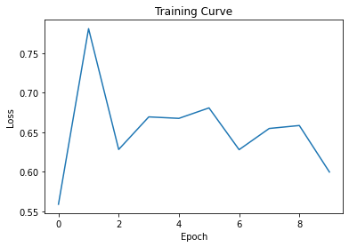

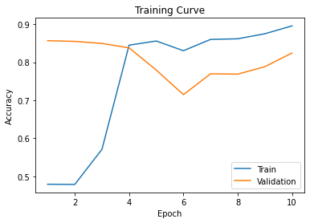

```python
model1 = smsRNN(50, 111, 2)
train_network(model1, train_iter, val_iter, num_epochs=10, learning_rate=1e-5)
```

### Part (c) [2 pt]

Choose at least 4 hyperparameters to tune. Explain how you tuned the hyperparameters. You don't need to include your training curve for every model you trained. Instead, explain what hyperparemters you tuned, what the best validation accuracy was, and the reasoning behind the hyperparameter decisions you made.

For this assignment, you should tune more than just your learning rate and epoch. Choose at least 2 hyperparameters that are unrelated to the optimizer.

```python
class smsRNN1(nn.Module):
  def __init__(self, input_size, hidden_size, num_classes):
    super(smsRNN1, self).__init__()

    self.emb = nn.Embedding.from_pretrained(glove.vectors)
    self.hidden_size = hidden_size
    self.rnn = nn.RNN(input_size, hidden_size, batch_first=True)
    self.fc1 = nn.Linear(hidden_size, 15)
    self.fc2 = nn.Linear(15, num_classes)


  def forward(self, x):
      # Look up the embedding
      x = self.emb(x)
      # Set an initial hidden state
      h0 = torch.zeros(1, x.size(0), self.hidden_size)


      # Forward propagate the RNN
      out, _ = self.rnn(x, h0)
      # Pass the output of the last time step to the classifier
      out = self.fc1(torch.max(out, dim=1)[0])
      out = self.fc2(out)
      return out
```

```python
def train_network1(model, train, valid, num_epochs, learning_rate):
    criterion = nn.CrossEntropyLoss()
    optimizer = torch.optim.Adam(model.parameters(), lr=learning_rate)

    losses, train_acc, valid_acc = [], [], []
    epochs = []
    for epoch in range(num_epochs):
        for sms, labels in train:
            optimizer.zero_grad()
            pred = model(sms[0])
            loss = criterion(pred, labels)
            loss.backward()
            optimizer.step()

        losses.append(float(loss))
        epochs.append(epoch+1)
        train_acc.append(get_accuracy(model, train))
        valid_acc.append(get_accuracy(model, valid))

    path = "lr{0}_epoch{1}".format(learning_rate,num_epochs)
    torch.save(model.state_dict(), path)
    print("Epoch %d; Loss %f; Train Acc %f; Val Acc %f" % (
              epoch+1, loss, train_acc[-1], valid_acc[-1]))
```

```python
# add one more fully connected layer to classifier
model2 = smsRNN1(50,111,2)
train_network1(model2, train_iter, val_iter, num_epochs=10, learning_rate=1e-5)
```

```
Epoch 10; Loss 0.680869; Train Acc 0.785158; Val Acc 0.609865
```

first, I add more more fully connected layer to the classifier in order to increase the complexity of the model to see if it can generate a good result.

```python
# tune hidden size to 50(same as the input size)
model3 = smsRNN(50, 50, 2)
train_network1(model3, train_iter, val_iter, num_epochs=10, learning_rate=1e-5)
```

```
Epoch 10; Loss 0.676486; Train Acc 0.826901; Val Acc 0.715695
```

From the previous step, I found both train and val accuracy are decreasing. So I decided to use the original model and tune the hidden size to 50 and check if the original model is over complexity.

```python
# tune num_epochs to 20
model1 = smsRNN(50, 111, 2)
train_network1(model1, train_iter, val_iter, num_epochs=20, learning_rate=1e-5)
```

```
Epoch 20; Loss 0.577389; Train Acc 0.928276; Val Acc 0.900448
```

Although the result of the previous step is better, the result is still not good enough. Hence I decided to remain using the original model with its original parameters. Next step, I chose to increase the number of epoch since from the training and validation accuracy curve, both curves have the increasing trend. so increase number of epoch may cause a better training.

```python
# tune learning rate to 1e-3
model4 = smsRNN(50, 111, 2)
train_network1(model4, train_iter, val_iter, num_epochs=10, learning_rate=1e-3)
```

```
Epoch 10; Loss 0.092885; Train Acc 0.985642; Val Acc 0.974888
```

When increasing the number of epoches, the result is getting better, but the difference is not that large. Hence the last step I decided to tune the learning rate slightly and that could also help me to avoid local minima.

### Part (d) [1 pt]

Before we deploy a machine learning model, we usually want to have a better understanding of how our model performs beyond its validation accuracy. An important metric to track is *how well our model performs in certain subsets of the data*.

In particular, what is the model's error rate amongst data with negative labels? This is called the **false positive rate**.

What about the model's error rate amongst data with positive labels? This is called the **false negative rate**.

Report your final model's false positive and false negative rate across the validation set.

```python
# Create a Dataset of only spam validation examples
valid_spam = torchtext.legacy.data.Dataset(
    [e for e in valid.examples if e.label == 1],
    valid.fields)

# Create a Dataset of only non-spam validation examples
valid_nospam = torchtext.legacy.data.Dataset(
    [e for e in valid.examples if e.label == 0],
    valid.fields) # TODO
```

```python
valid_spam_iter =torchtext.legacy.data.BucketIterator(valid_spam,
                                           batch_size=32,
                                           sort_key=lambda x: len(x.sms), # to minimize padding
                                           sort_within_batch=True,        # sort within each batch
                                           repeat=False)
valid_nospam_iter = torchtext.legacy.data.BucketIterator(valid_nospam,
                                           batch_size=32,
                                           sort_key=lambda x: len(x.sms), # to minimize padding
                                           sort_within_batch=True,        # sort within each batch
                                           repeat=False)
```

```python
model4 = smsRNN(50, 111, 2)
path = "lr{0}_epoch{1}".format(1e-3,10)
state = torch.load(path)
model4.load_state_dict(state)
```

```
<All keys matched successfully>
```

```python
print("The model's false positive rate is {}.".format(1 - get_accuracy(model4, valid_nospam_iter)))

print("The model's false negative rate is {}.".format(1 - get_accuracy(model4, valid_spam_iter)))
```

```
The model's false positive rate is 0.014403292181069949.
The model's false negative rate is 0.09790209790209792.
```

### Part (e) [1 pt]

The impact of a false positive vs a false negative can be drastically different. If our spam detection algorithm was deployed on your phone, what is the impact of a false positive on the phone's user? What is the impact of a false negative?

A false positive means the algorithm detects the message as a spam message and block it but it is actual a ham message. That may cause the user missed some important information sent from other people and this could cause a significant impact.

A false negative means the algorithm detects the message as a ham message but it is actual spam message. This may cause the user may receive some spam messages.

## Part 4. Evaluation [7 pt]

### Part (a) [1 pt]

Report the final test accuracy of your model.

```python
print("The model's test accuract is {}.".format(get_accuracy(model4, test_iter)))
```

```
The model's test accuract is 0.9784560143626571.
```

### Part (b) [1 pt]

Report the false positive rate and false negative rate of your model across the test set.

```python
# Create a Dataset of only spam test examples
test_spam = torchtext.legacy.data.Dataset(
    [e for e in test.examples if e.label == 1],
    test.fields)

# Create a Dataset of only non-spam test examples
test_nospam = torchtext.legacy.data.Dataset(
    [e for e in test.examples if e.label == 0],
    test.fields) # TODO
```

```python
test_spam_iter =torchtext.legacy.data.BucketIterator(test_spam,
                                           batch_size=32,
                                           sort_key=lambda x: len(x.sms), # to minimize padding
                                           sort_within_batch=True,        # sort within each batch
                                           repeat=False)
test_nospam_iter = torchtext.legacy.data.BucketIterator(test_nospam,
                                           batch_size=32,
                                           sort_key=lambda x: len(x.sms), # to minimize padding
                                           sort_within_batch=True,        # sort within each batch
                                           repeat=False)
```

```python
print("The model's test false positive rate is {}.".format(1 - get_accuracy(model4, test_nospam_iter)))

print("The model's test false negative rate is {}.".format(1 - get_accuracy(model4, test_spam_iter)))
```

```
The model's test false positive rate is 0.009221311475409832.
The model's test false negative rate is 0.09420289855072461.
```

### Part (c) [3 pt]

What is your model's prediction of the **probability** that the SMS message "machine learning is sooo cool!" is spam?

Hint: To begin, use `text_field.vocab.stoi` to look up the index of each character in the vocabulary.

```python
msg = "machine learning is sooo cool!"

msg_emb = []
print(text_field.vocab.stoi)

for i in msg:
  msg_emb.append(torch.tensor(text_field.vocab.stoi[i]))

idxs = torch.tensor(msg_emb)

print("the probability that the message is dected as spam message is :", torch.softmax(model4(idxs.unsqueeze(0)), dim=1)[0][1].item())
```

```
defaultdict(<bound method Vocab._default_unk_index of <torchtext.vocab.Vocab object at 0x7faad8cdd810>>, {'<unk>': 0, '<pad>': 1, ' ': 2, 'e': 3, 'o': 4, 't': 5, 'a': 6, 'n': 7, 'i': 8, 's': 9, 'r': 10, 'l': 11, 'h': 12, 'u': 13, '.': 14, 'd': 15, 'y': 16, 'm': 17, 'c': 18, 'g': 19, 'w': 20, 'p': 21…
the probability that the message is dected as spam message is : 0.0013892136048525572
```

### Part (d) [2 pt]

Do you think detecting spam is an easy or difficult task?

Since machine learning models are expensive to train and deploy, it is very important to compare our models against baseline models: a simple model that is easy to build and inexpensive to run that we can compare our recurrent neural network model against.

Explain how you might build a simple baseline model. This baseline model can be a simple neural network (with very few weights), a hand-written algorithm, or any other strategy that is easy to build and test.

**Do not actually build a baseline model. Instead, provide instructions on how to build it.**

In our daily life we often use spam detection algorithm. Because of the pervasiveness of the internet, we need a more efficient way to obtain information such as only receive useful messages. So nowdays, this algorithm is getting matured.so in my opinion, this is an easy task compared to other algorithms.

I think we can not only look for correlations between spam messages or ham messages, but also could try to compile a "dictionary" of words that often appear in spam messages that received in the past.And use it as a comparison. The dictionary can not only have words but also some unreasonable characters.

# PART B - Transfer Learning [20 pt]

In this part we will compare our earlier model with one that takes advantage of a generative RNN model to improve the prediction. There are several ways to implement transfer learning with RNNs, here we will use an approach known as ULMFiT developed by fastai. Rather than rebuilding the model from scratch, we will take advantage of the fastai library.

Provided below is some helper code to get you started.

#### Helper Code

```python
# install relevant libraries
!pip install spacy==2.3.5
!pip install fastai==1.0.61
```

[output not shown]

```python
# load relevant libraries
from fastai import *
import pandas as pd
import numpy as np
from functools import partial
import io
import os
from fastai.text import *
```

```python
# download SPAM data
!wget https://archive.ics.uci.edu/ml/machine-learning-databases/00228/smsspamcollection.zip
!unzip smsspamcollection.zip
```

```
--2022-11-21 02:04:28--  https://archive.ics.uci.edu/ml/machine-learning-databases/00228/smsspamcollection.zip
Resolving archive.ics.uci.edu (archive.ics.uci.edu)... 128.195.10.252
Connecting to archive.ics.uci.edu (archive.ics.uci.edu)|128.195.10.252|:443... connected.
HTTP request sent, awaiting response... 200 OK
Length: 203415 (199K) [application/x-httpd-php]
Saving to: ‘smsspamcollection.zip’

smsspamcollection.z 100%[===================>] 198.65K   304KB/s    in 0.7s

2022-11-21 02:04:29 (304 KB/s) - ‘smsspamcollection.zip’ saved [203415/203415]

Archive:  smsspamcollection.zip
  inflating: SMSSpamCollection
  inflating: readme
```

This time we will load the data using pandas.

```python
# set up data and verify
df1 = pd.read_csv('SMSSpamCollection', sep='\t',  header=None, names=['target', 'text'])
df1.head()
```

|  | target | text |
| --- | --- | --- |
| 0 | ham | Go until jurong point, crazy.. Available only ... |
| 1 | ham | Ok lar... Joking wif u oni... |
| 2 | spam | Free entry in 2 a wkly comp to win FA Cup fina... |
| 3 | ham | U dun say so early hor... U c already then say... |
| 4 | ham | Nah I don't think he goes to usf, he lives aro... |

```python
# check distribution
df1['target'].value_counts()
```

```
ham     4825
spam     747
Name: target, dtype: int64
```

Split the data into training and validation datasets.

```python
# split the data and check dimensions

from sklearn.model_selection import train_test_split

# split data into training and validation set
df_trn, df_val = train_test_split(df1, stratify = df1['target'], test_size = 0.3, random_state = 999)
```

```python
df_trn.shape, df_val.shape
```

```
((3900, 2), (1672, 2))
```

### Create the language model

Esentially, the language model contains the structure of the language (English in this case), allowing us to quickly use in a classification model, skipping the part of learning the semantics of the language from scratch.

Creating a language model from scratch can be intensive due to the sheer size of data. Instead we will download the pre-trained model, which is a neural network (NN) with an AWD_LSTM architecture. By setting pretrained = True we say to fastai to download the weights from the trained model (a corpus of 103 MM of wikipedia articles).

```python
# create pretrained language model data
data_lm = TextLMDataBunch.from_df(train_df = df_trn, valid_df = df_val, path = "")

lang_mod = language_model_learner(data_lm, arch = AWD_LSTM, pretrained = True, drop_mult=1.)
```

```python
#!pip install torch==1.8.0+cu111 torchvision==0.9.0+cu111 torchaudio==0.8.0 -f https://download.pytorch.org/whl/torch_stable.html
```

[output not shown]

### Testing the language model

```python
for i in range(5):
  print(lang_mod.predict("The problem usually starts when", n_words=10))
```

```
The problem usually starts when over a yoga class is done during a night night
The problem usually starts when it is set up and ends at a where -
The problem usually starts when Indian Head Indian Head ,
The problem usually starts when Roger Christmas ( christmas christmas christmas christmas christmas christmas ) ) ) ) ) ) was was was was was was
The problem usually starts when a man ( often in a car ) is called
```

Each time we excecute the `predict`, we get a different random sentence, completed with the number of choosen words (`n_words`).

Try your own sentences!

### Fine-tuning the language model

The language model that we have "loaded" is great for generating wikipedia-like sentances, but here we're more interested in generating data like our email dataset.

Make sure to enable GPU for this step or it make takes several hours to train.

```python
# fine-tune language model data
lang_mod.fit_one_cycle(4, max_lr= 5e-02)
lang_mod.freeze_to(-1)
lang_mod.fit_one_cycle(3, slice(1e-2/(2.6**4), 1e-2))
lang_mod.freeze_to(-2)
lang_mod.fit_one_cycle(3, slice(3e-3/(2.6**4), 1e-3))
lang_mod.unfreeze()
lang_mod.fit_one_cycle(3, slice(3e-3/(2.6**4), 1e-3))

# save language model
lang_mod.save_encoder('my_awsome_encoder')
```

| epoch | train_loss | valid_loss | accuracy | time |
| --- | --- | --- | --- | --- |
| 0 | 5.552319 | 3.906959 | 0.285714 | 00:02 |
| 1 | 4.844585 | 3.958570 | 0.257143 | 00:02 |
| 2 | 4.394514 | 3.783814 | 0.300000 | 00:02 |
| 3 | 4.071576 | 3.760698 | 0.285714 | 00:02 |

| epoch | train_loss | valid_loss | accuracy | time |
| --- | --- | --- | --- | --- |
| 0 | 3.566992 | 3.761557 | 0.271429 | 00:02 |
| 1 | 3.546834 | 3.756828 | 0.271429 | 00:02 |
| 2 | 3.487672 | 3.743930 | 0.271429 | 00:02 |

| epoch | train_loss | valid_loss | accuracy | time |
| --- | --- | --- | --- | --- |
| 0 | 3.400414 | 3.725554 | 0.285714 | 00:02 |
| 1 | 3.373869 | 3.728175 | 0.257143 | 00:02 |
| 2 | 3.353397 | 3.723139 | 0.257143 | 00:02 |

| epoch | train_loss | valid_loss | accuracy | time |
| --- | --- | --- | --- | --- |
| 0 | 3.322366 | 3.702986 | 0.271429 | 00:03 |
| 1 | 3.282937 | 3.699495 | 0.285714 | 00:03 |
| 2 | 3.262885 | 3.697048 | 0.285714 | 00:03 |

### Classification model

Now we can train a classification model that will identify spam and non-spam messages. Since we used a fastai language model, it will be easier to just continue working with the fastai library.

```python
# Classifier model data
data_clas = TextClasDataBunch.from_df(path = "", train_df = df_trn,  valid_df = df_val, vocab=data_lm.train_ds.vocab, bs=32)
```

```python
data_clas.show_batch()
```

| text | target |
| --- | --- |
| xxbos xxmaj the last thing i ever wanted to do was hurt you . xxmaj and i did n't think it would have . xxmaj you 'd laugh , be embarassed , delete the xxunk and keep going . xxmaj but as far as i kne… | ham |
| xxbos a xxmaj boy loved a gal . xxmaj he xxunk bt she did nt mind . xxmaj he xxunk xxunk xxunk , xxmaj bt her frnds xxunk xxunk . xxmaj again d boy decided 2 xxunk d gal , xxunk time a xxunk was xxunk… | ham |
| xxbos xxmaj solve d xxmaj case : a xxmaj man xxmaj was xxmaj found xxmaj murdered xxmaj on < xxup decimal > . < # > afternoon . 1,his wife called xxmaj police . 2,police questioned everyone . 3,wife :… | ham |
| xxbos xxmaj storming msg : xxmaj wen u lift d phne , u say " xxup hello " xxmaj do u knw wt is d real meaning of xxup hello ? ? . . . xxmaj it 's d name of a girl .. ! . . . xxmaj yes .. xxmaj and u k… | ham |
| xxbos xxmaj you are everywhere xxunk , on the floor , the windows , even on my shirt . xxmaj and sometimes when i open my xxunk , you are all that comes xxunk out . i dream of my world without you , t… | ham |

```python
# create the classifier
learn_classifier = text_classifier_learner(data_clas, drop_mult=0.7, arch = AWD_LSTM)
```

```python
# load language model
learn_classifier.load_encoder('my_awsome_encoder')
```

[output not shown]

[output cut: 34 more lines]

[output not shown]

[output not shown]

```
LR Finder is complete, type {learner_name}.recorder.plot() to see the graph.
Min numerical gradient: 1.74E-01
Min loss divided by 10: 2.51E-02
```

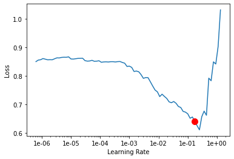

```python
# train classifier
learn_classifier.lr_find()
learn_classifier.recorder.plot(suggestion=True)
```

```python
learn_classifier.fit_one_cycle(5, max_lr=1e-2, moms=(0.8,0.7))
```

| epoch | train_loss | valid_loss | accuracy | time |
| --- | --- | --- | --- | --- |
| 0 | 0.428532 | 0.063987 | 0.982656 | 00:03 |
| 1 | 0.195063 | 0.082236 | 0.980861 | 00:03 |
| 2 | 0.099600 | 0.073220 | 0.982656 | 00:03 |
| 3 | 0.094562 | 0.084822 | 0.986244 | 00:03 |
| 4 | 0.088443 | 0.080665 | 0.983254 | 00:03 |

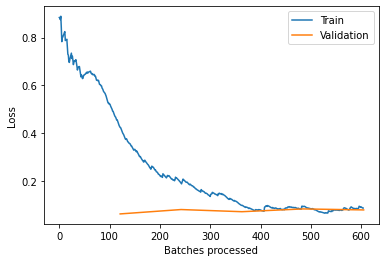

```python
learn_classifier.recorder.plot_losses()
```

[output not shown]

```
LR Finder is complete, type {learner_name}.recorder.plot() to see the graph.
Min numerical gradient: 6.31E-07
Min loss divided by 10: 4.37E-06
```

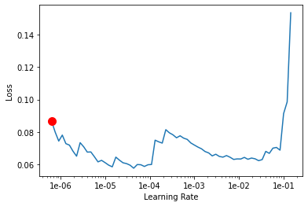

```python
lang_mod.freeze_to(-1)

learn_classifier.lr_find()
learn_classifier.recorder.plot(suggestion=True)
```

Test out the classification model on spam and non-spam examples.

```python
# predict
learn_classifier.predict('did you buy the groceries for dinner? :)')
```

```
(Category tensor(0), tensor(0), tensor([0.9921, 0.0079]))
```

```python
# predict
learn_classifier.predict('Free entry call back now')
```

```
(Category tensor(1), tensor(1), tensor([0.4062, 0.5938]))
```

Next we will evaluate on all of our validation data.

```python
# get predictions from validation
valid_preds, valid_label=learn_classifier.get_preds(ds_type=DatasetType.Valid, ordered=True)
valid_preds.shape
```

```
torch.Size([1672, 2])
```

## Part 1. Evaluate Performance [10pt]

### Part (a) [5pt]

Implement the above helper code for spam detection.

What is the accuracy obtained with ULMFiT? How does ULMFiT compare to the approach in the first part using only LSTM?

the accuracy obtained with ULMFiT is around 98.4% while the accuracy with LSTM is around 97.8%. Compared the results, the language model could potentially imporve the result.

### Part (b) [5pt]

Provide a confusion matrix of the performance for the two models. How do they compare? Are there any qualitative differences between the performances (i.e. examine the samples for which the models differred)?

```python
from sklearn.metrics import confusion_matrix
# confusion matrix for language model

preds=valid_preds.numpy()
val_target=preds[:,1] > 0.05 #set threshold = 0.05

df_val['class'] = val_target
df_val['class'] = df_val['class'].replace([False,True],['ham','spam'])

# confusion matrix for language model
cm = confusion_matrix(df_val['target'],df_val['class'])
cm
```

```
array([[1409,   39],
       [   8,  216]])
```

```python
# confusion matrix for part 1 model

import pandas as pd
def cm_dataframe(model, data):

    pred_ = []
    labels_ = []
    for sms, labels in data:
        output = model(sms[0])
        pred = output.max(1, keepdim=True)[1]

        pred_.append(pred.tolist()[0][0])
        labels_.append(labels.tolist()[0])

    d = {'prediction': pred_, 'labels': labels_}
    df = pd.DataFrame(data=d)

    df['prediction'] = df['prediction'].replace([0,1],['ham','spam'])
    df['labels'] = df['labels'].replace([0,1],['ham','spam'])

    return df


df1 = cm_dataframe(model4, test_iter)
```

```python
from sklearn.metrics import confusion_matrix
confusion_matrix(df1['prediction'],df1['labels'])
```

```
array([[31,  0],
       [ 1,  3]])
```

compared these two results, the language model identifed some messages as spam messages while they are actually ham messages.

## Part 2. Evaluate on New Data [10pt]

### Part (a) [4pt]

What is your model's prediction of the probability that the SMS message "machine learning is sooo cool!" is spam?

```python
msg = "machine learning is sooo cool!"

msg_emb = []
print(text_field.vocab.stoi)

for i in msg:
  msg_emb.append(torch.tensor(text_field.vocab.stoi[i]))

idxs = torch.tensor(msg_emb)

print("the probability that the message is dected as spam message is :", torch.softmax(model4(idxs.unsqueeze(0)), dim=1)[0][1].item())
```

```
defaultdict(<bound method Vocab._default_unk_index of <torchtext.vocab.Vocab object at 0x7faad8cdd810>>, {'<unk>': 0, '<pad>': 1, ' ': 2, 'e': 3, 'o': 4, 't': 5, 'a': 6, 'n': 7, 'i': 8, 's': 9, 'r': 10, 'l': 11, 'h': 12, 'u': 13, '.': 14, 'd': 15, 'y': 16, 'm': 17, 'c': 18, 'g': 19, 'w': 20, 'p': 21…
the probability that the message is dected as spam message is : 0.0013892136048525572
```

### Part (b) [3 pt]

Load 5 sample sentences from your spam mail and test it out out the two models you created. How well do they perform?

```python
def rnn_spam(m):
  m_emb = []

  for i in m:
    m_emb.append(torch.tensor(text_field.vocab.stoi[i]))

  idxs = torch.tensor(m_emb)

  return("the probability that the message is dected as spam message is :", torch.softmax(model4(idxs.unsqueeze(0)), dim=1)[0][1].item())

def lang_spam(m):
  return ("the probability using language model(detecting as spam):", learn_classifier.predict(m)[2][1].tolist())
```

```python
msg1 = "Go to http://bit.ly/123456 tp claim now"
msg2 = "Get your free Bitcoin RIGHT NOW"
msg3 = "**You've won! Get a $1000 gift card!**"
msg4 = "Must accept your rewards with 24 hours:"
msg5 = "Free Msg: call 098765"
```

```python
print(lang_spam(msg1))
print(lang_spam(msg2))
print(lang_spam(msg3))
print(lang_spam(msg4))
print(lang_spam(msg5))
```

```
('the probability using language model(detecting as spam):', 0.8188122510910034)
('the probability using language model(detecting as spam):', 0.4723905026912689)
('the probability using language model(detecting as spam):', 0.421891987323761)
('the probability using language model(detecting as spam):', 0.005753293167799711)
('the probability using language model(detecting as spam):', 0.7430142164230347)
```

```python
print(rnn_spam(msg1))
print(rnn_spam(msg2))
print(rnn_spam(msg3))
print(rnn_spam(msg4))
print(rnn_spam(msg5))
```

```
('the probability that the message is dected as spam message is :', 0.061090968549251556)
('the probability that the message is dected as spam message is :', 0.07714369893074036)
('the probability that the message is dected as spam message is :', 0.7682791948318481)
('the probability that the message is dected as spam message is :', 0.00763779878616333)
('the probability that the message is dected as spam message is :', 0.9654040336608887)
```

both the language model and the model from part 1 successfully dected 2 spam messages. (ie. >50%). But the overall prediction of language model is better. for example there are 2 messages has probability aroun 45%, which is really close to 50%.

### Part (c) [3pt]

Load 5 sample sentences from your regular mail and test it out out the two models you created. How well do they perform?

```python
msg1 = "Call me when you arrived"
msg2 = "See you then."
msg3 = "Can you buy me a chocolate bar?"
msg4 = "I've already booked the flight"
msg5 = "let's go have the breakfast"
```

```python
print(lang_spam(msg1))
print(lang_spam(msg2))
print(lang_spam(msg3))
print(lang_spam(msg4))
print(lang_spam(msg5))
```

```
('the probability using language model(detecting as spam):', 1.1484943570394535e-05)
('the probability using language model(detecting as spam):', 3.6554492072182754e-11)
('the probability using language model(detecting as spam):', 0.011908628977835178)
('the probability using language model(detecting as spam):', 2.4835577672847543e-20)
('the probability using language model(detecting as spam):', 4.0045622881734744e-05)
```

```python
print(rnn_spam(msg1))
print(rnn_spam(msg2))
print(rnn_spam(msg3))
print(rnn_spam(msg4))
print(rnn_spam(msg5))
```

```
('the probability that the message is dected as spam message is :', 0.002380438381806016)
('the probability that the message is dected as spam message is :', 0.0011915909126400948)
('the probability that the message is dected as spam message is :', 0.0020138092804700136)
('the probability that the message is dected as spam message is :', 0.0012358822859823704)
('the probability that the message is dected as spam message is :', 0.0018613579450175166)
```

### Saving to HTML

Detailed instructions for saving to HTML can be found [here](https://stackoverflow.com/questions/53460051/convert-ipynb-notebook-to-html-in-google-colab/64487858#64487858). Provided below are a summary of the instructions:

(1) download your ipynb file by clicking on File->Download.ipynb

(2) reupload your file to the temporary Google Colab storage (you can access the temporary storage from the tab to the left)

(3) run the following:

```python
%%shell
jupyter nbconvert --to html LAB_4_Sequential_Data.ipynb
```

[output not shown]

(4) the html file will be available for download in the temporary Google Colab storage

(5) review the html file and make sure all the results are visible before submitting your assignment to Quercus